# Сессия 3

## Импортирование библиотек и загрузка данных

```python
#Импорт бибилиотек
import pandas as pd
import numpy as np
import matplotlib.pyplot as plt
pd.set_option("display.max_columns", None)
plt.style.use('dark_background')
warnings.filterwarnings('ignore')
```

```python
#Загрузка данных из предыдущей сессии
df=pd.read_csv('result_data.csv', sep='\t',encoding='utf-8-sig')
df=df.iloc[:,1:]
```

```python
df.head()
```

|  | properties.id | properties.gibdd_id | properties.point.lat | properties.point.long | properties.participant_categories | properties.severity | properties.region | properties.parent_region | properties.datetime | properties.address | properties.participants_count | properties.injured_count | properties.dead_count | properties.category | properties.light | properties.nearby | properties.weather | properties.road_conditions | properties.vehicles | properties.participants | properties.tags | properties.scheme | Все участники | Дети | Пешеходы | Мотоциклисты | Велосипедисты | Общ. транспорт | Нерегулируемый перекрёсток неравнозначных улиц (дорог) | … |
| --- | --- | --- | --- | --- | --- | --- | --- | --- | --- | --- | --- | --- | --- | --- | --- | --- | --- | --- | --- | --- | --- | --- | --- | --- | --- | --- | --- | --- | --- | --- |
| 0 | 2312860 | 191156006 | 53.775400 | 82.667800 | ['Все участники'] | Легкий | Павловский район | Алтайский край | 2016-02-16 21:50:00 | Барнаул - Камень-на-Оби - граница Новосибирско... | 3 | 1 | 0 | Столкновение | В темное время суток, освещение отсутствует | [] | ['Ясно'] | ['Сухое'] | [{'brand': 'NISSAN', 'model': 'Serena', 'color... | [] | ['Дорожно-транспортные происшествия'] | 210 | 1 | 0 | 0 | 0 | 0 | 0 | 0 | … |
| 1 | 2310071 | 220071393 | 53.401953 | 82.236507 | ['Все участники'] | Тяжёлый | Шелаболихинский район | Алтайский край | 2019-11-04 01:10:00 | Барнаул - Камень-на-Оби - граница Новосибирско... | 1 | 1 | 0 | Опрокидывание | В темное время суток, освещение отсутствует | [] | ['Пасмурно'] | ['Сухое'] | [{'brand': 'TOYOTA', 'model': 'Corolla', 'colo... | [] | ['Дорожно-транспортные происшествия'] | 950 | 1 | 0 | 0 | 0 | 0 | 0 | 0 | … |
| 2 | 2311255 | 206911348 | 53.324525 | 83.007579 | ['Все участники'] | Легкий | Павловский район | Алтайский край | 2017-09-25 11:50:00 | Барнаул - Камень-на-Оби - граница Новосибирско... | 3 | 2 | 0 | Столкновение | Светлое время суток | [] | ['Пасмурно'] | ['Сухое'] | [{'brand': 'MITSUBISHI', 'model': 'Pajero', 'c... | [] | ['Дорожно-транспортные происшествия'] | 60 | 1 | 0 | 0 | 0 | 0 | 0 | 0 | … |
| 3 | 2308403 | 213560316 | 53.320377 | 82.917423 | ['Дети', 'Все участники'] | Тяжёлый | Павловский район | Алтайский край | 2018-11-03 11:00:00 | Павловск - Ребриха - Буканское, 65 км | 4 | 2 | 0 | Столкновение | Светлое время суток | [] | ['Снегопад'] | ['Сухое'] | [{'brand': 'ВАЗ', 'model': 'ВАЗ 2110, 21101, 2... | [] | ['Дорожно-транспортные происшествия', 'ДТП и п... | 220 | 1 | 1 | 0 | 0 | 0 | 0 | 0 | … |
| 4 | 2313040 | 191027864 | 52.988900 | 82.155600 | ['Все участники'] | Легкий | Ребрихинский район | Алтайский край | 2016-02-02 04:20:00 | Павловск - Ребриха - Буканское, 65 км | 2 | 1 | 0 | Опрокидывание | В темное время суток, освещение отсутствует | ['Нерегулируемый перекрёсток'] | ['Пасмурно'] | ['Обработанное противогололедными материалами'] | [{'brand': 'DAF', 'model': 'CF-series', 'color... | [] | ['Дорожно-транспортные происшествия'] | 600 | 1 | 0 | 0 | 0 | 0 | 0 | 0 | … |

```python
df.info()
```

```
<class 'pandas.core.frame.DataFrame'>
RangeIndex: 928453 entries, 0 to 928452
Columns: 167 entries, properties.id to named_roads
dtypes: float64(3), int64(149), object(15)
memory usage: 1.2+ GB
```

## 3.1 Визуализация зависимостей данных

Чтобы визуализировать зависимости данных, необходимо сначала получить модели классификации по которым будет визуализация зависимостей атрибутов на целевую переменную

### Способы визуализации

1. График кривой ошибок
2. Столбчатая диаграмма
3. Корреляционная карта атрибутиов

**Обоснование выбора данных способов: данные способы были выбранны, поскольку с помощью них можно интерпритировать все необходимую информацию по зависомостям целевой переменной от атрибутов и информацию об уровнях опасности. А также потому что их проще всего визуализировать и проинтеритировать**

### Визуализируемые методы(то, что будет визуализироваться)

1. Кривая ошибок, где можно интерпритировать зависимость доли верных положительных классификаций от доли ложных положительных классификаций на целевой переменной
2. Данные точности 3-ёх моделей
3. Корреляция атрибутов на целевую переменную

**Обоснование выбора этих методов: данные методы были выбранны, поскольку они будут предоставлять информацию о всех возможных зависимостях атрибутов на целевую переменную, а также дадут возможность интерпритировать эти данных**

## 3.2 Классификация дорожных объектов

### Алгоритмы классификации

Рассмотрим 3 модели классификации

### Логистическая регрессия

Логистическая регрессия - метод построения линейного классификатора, позволяющий оценивать апостериорные вероятности принадлежности объектов классам

### Наивный байесовский классификатор

Наивный байесовский классификатор (naїve Bayes) — специальный частный случай байесовского классификатора, основанный на дополнительном предположении, что объекты x пренадлежат X описываются n статистически независимыми признаками

### Дерево принятия решений

Дерево принятия решений - средство поддержки принятия решений, использующееся в машинном обучении, анализе данных и статистике. Структура дерева представляет собой «листья» и «ветки». На рёбрах («ветках») дерева решения записаны признаки, от которых зависит целевая функция, в «листьях» записаны значения целевой функции, а в остальных узлах — признаки, по которым различаются случаи. Чтобы классифицировать новый случай, надо спуститься по дереву до листа и выдать соответствующее значение

**Обоснование выбора данных моделей: данные алгоритмы были выбранны, поскольку они способны быстро работать с большим количеством данных, а также имеют простое концептуальное решение, не требующее особых настроек в параметрах. Для сравнения можно привести модель, которая работает на нейронах и требует "жёсткой" настройки параметров - `sequential`**

```python
from sklearn.linear_model import LogisticRegression
from sklearn.naive_bayes import GaussianNB
from sklearn.tree import DecisionTreeClassifier
```

## Выбор метрик

Чтобы определить наилучшую модель можно воспользоваться такими метриками, как `Точность(Accuracy)`, `Стандартная функция потерь(Loss func или Log func)` и `Кривая ошибок(Roc-curve)`

**Обоснование выбора данных метрик: данные метрики были выбранны, поскольку они предоставляют всю необходимую информацию для определения наилучшей модели в виде точности, количества ошибок модели и зависимость доли верных положительных классификаций от доли ложных положительных классификаций**

```python
from sklearn.metrics import accuracy_score, roc_curve, auc, log_loss
```

## Стандартизация данных

Стандартизация необходима для получения минимальной разобщённости данных, а также для масштабирования данных

```python
from sklearn.preprocessing import StandardScaler
```

```python
features=df.drop(['properties.id', 'properties.gibdd_id', 'properties.point.lat', 'properties.point.long',
           'properties.participant_categories', 'properties.severity', 'properties.region',
           'properties.parent_region', 'properties.datetime', 'properties.address', 'properties.category',
           'properties.light', 'properties.nearby', 'properties.weather', 'properties.road_conditions',
           'properties.vehicles', 'properties.participants', 'properties.tags', 'properties.scheme', 'kmeans_preds_all','named_roads'],axis=1)

scaler=StandardScaler()
X=scaler.fit_transform(features)
```

## Разбиение набора данных

Разобъём набор данных по такому же принципу, как и в прошлой сессии 1/3. Обоснование приведенно

**Обоснование разбиения набора данных: разбиение набора данных на обучающую и тестирующую выборки будут произведенны на основании официального сайта функций машинного обучение - `scikit-learn`. Данная библиотека предоставляет метод разбиения данных https://scikit-learn.org/stable/modules/generated/sklearn.model_selection.train_test_split.html, в котором демонстрируется реккомендуемая выборка 1/3. Данное значение можно обусловить тем, что для обучения требуется больше данных, чем для тестирование. Чтобы, и в тестовой выборке, и в тренеровочной имелись данные для всех регионов, воспользуемся аргументом, `shuffle`, который распределит данные таким образом, чтобы уникальность значений в каждом из наборов, была максимальна**

```python
from sklearn.model_selection import train_test_split
```

```python
#1/3 - это значит, что тестовая выборка будет иметь 0.33 данных
from sklearn.model_selection import train_test_split
X_train, X_test, y_train, y_test = train_test_split(X, df['kmeans_preds_all'], test_size=0.33, random_state=42, shuffle=True)
```

## Функция обучения

Чтобы не интерпретировать каждый раз те же методы, зафиксируем это всё в функции `get_model`

```python
def get_model(model, X_train, X_test, y_train, y_test):
    model_fit=model.fit(X_train, y_train)
    model_preds=model_fit.predict(X_test)
    y_prob = model_fit.predict_proba(X_test)[:,1]

    accuracy_metric=accuracy_score(y_test, model_preds)
    log_loss_metric=log_loss(y_test, model_preds)
    false_positive_rate, true_positive_rate, thresholds = roc_curve(y_test, y_prob)
    roc_auc = auc(false_positive_rate, true_positive_rate)

    metrics={'Точность':accuracy_metric, 'Функция потерь':log_loss_metric, 'Кривая ошибки':roc_auc}

    #Визуализация
    plt.figure(figsize=(10,10))
    plt.title('График кривой ошибок(Roc-curve) на ' + str(model))
    plt.plot(false_positive_rate,true_positive_rate, color='red',label = 'AUC = %0.2f' % roc_auc)
    plt.legend(loc = 'lower right')
    plt.plot([0, 1], [0, 1],linestyle='--')

    plt.ylabel('Верные положительные классификации целевой переменной всех атрибутов')
    plt.xlabel('Ложные положительные классификации целевой переменной всех атрибутов')
    plt.show

    return model_fit, model_preds, metrics
```

## 3.3 Обучение

### Логистическая регрессия

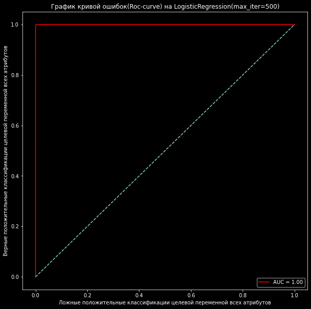

```python
model_logr=get_model(LogisticRegression(max_iter=500), X_train, X_test, y_train, y_test)
```

Интерпритация кривой логистичекой регрессии: на данном графике видно, что доля верных положительных классификации целевой переменной всех атрибутов от ложных положительных классификации целевой переменной всех атрибутов составляет `1.00`(вероятнее всего есть погрешность), что не может не радоавать, это значит, что классификатор на этих данных работает бузепречно

### Наивный байесовский классификатор

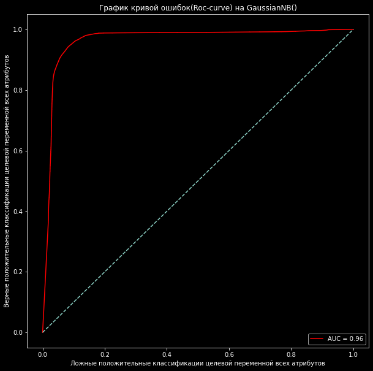

```python
model_gnb=get_model(GaussianNB(), X_train, X_test, y_train, y_test)
```

Интерпритация кривой навного Байесовского классификатора: на данном графике видно, что доля верных положительных классификации целевой переменной всех атрибутов от ложных положительных классификации целевой переменной всех атрибутов составляет `0.96`, это также хороший результат. Данные график демонстрирует закруглённую красную линию, это значит, что классификатор на таких атрибутах для данной целевой переменной имеет небольшое отклонение

### Дерево принятия решений

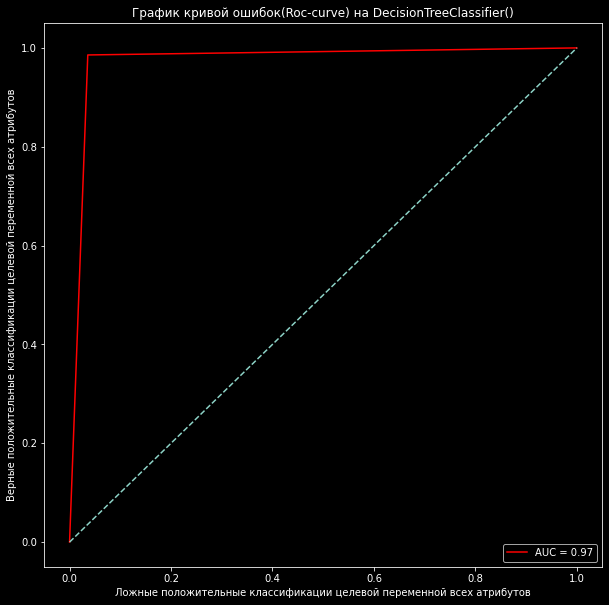

```python
model_dtc=get_model(DecisionTreeClassifier(), X_train, X_test, y_train, y_test)
```

## Резюмирование

**Рассмотрим расчёты определения уровня опасности по выбранным алгоритмам разных метрик. Вся интерпритация данным результатам будет дана ниже в визуализации**

```python
from pandas import json_normalize
```

```python
json_normalize(model_logr[2])
```

|  | Точность | Функция потерь | Кривая ошибки |
| --- | --- | --- | --- |
| 0 | 0.998459 | 0.053208 | 0.999986 |

```python
json_normalize(model_gnb[2])
```

|  | Точность | Функция потерь | Кривая ошибки |
| --- | --- | --- | --- |
| 0 | 0.808414 | 6.61715 | 0.964751 |

```python
json_normalize(model_dtc[2])
```

|  | Точность | Функция потерь | Кривая ошибки |
| --- | --- | --- | --- |
| 0 | 0.9787 | 0.735673 | 0.974907 |

**Вузиализируем данные в виде столбчатой диаграммы и приведём им интерпритацию. Напомню, что атрибуты были полученны из предыдущих сессий, где также присутствует информация о дорожной ситуации в виде индекса, а также количестве ДТП на один адрес**

```python
df[['properties.id', 'count_accedent', 'index_accedent']].head()
```

|  | properties.id | count_accedent | index_accedent |
| --- | --- | --- | --- |
| 0 | 2312860 | 3 | 0.010929 |
| 1 | 2310071 | 3 | 0.010929 |
| 2 | 2311255 | 3 | 0.013661 |
| 3 | 2308403 | 2 | 0.010929 |
| 4 | 2313040 | 2 | 0.008197 |

[figure not shown]

```python
x = ('Логистическая модель', 'Наивный байесовский классификатор', 'Дерево решений')
y = (list(model_logr[2].values())[0], list(model_gnb[2].values())[0], list(model_dtc[2].values())[0])

fig, ax = plt.subplots()

ax.bar(x, y)
ax.set_title('Визуализация влияния атрибутов на целевую переменную\nпо точности по выбранным алгоритмам')
fig.set_figwidth(12)    #  ширина Figure
fig.set_figheight(6)    #  высота Figure

ax.set_ylabel('Точность моделей')
ax.set_xlabel('Названия моделей')
plt.show()
```

Интерпритация столбчатой диаграммы выше: точность алгоритмов, которые были выбранны по всем атрибутам у всех неплохая, но самый лучший результат имеет логистическая регрессия с `0.99`

[figure not shown]

```python
x = ('Логистическая модель', 'Наивный байесовский классификатор', 'Дерево решений')
y = (list(model_logr[2].values())[1], list(model_gnb[2].values())[1], list(model_dtc[2].values())[1])

fig, ax = plt.subplots()

ax.bar(x, y)
ax.set_title('Визуализация влияния атрибутов на целевую переменную\nпо функции потерь по выбранным алгоритмам')
fig.set_figwidth(12)    #  ширина Figure
fig.set_figheight(6)    #  высота Figure

ax.set_ylabel('Значение функции потерь')
ax.set_xlabel('Названия моделей')
plt.show()
```

Интерпритация столбчатой диаграммы выше: напомню, что функциия потерь рассчитывает все возможные потери при неправильном решении классификатора. В данной диаграмме видно, что наименьший показатель функции потерь имеет логистическая регрессия, на уровне - `0.05`

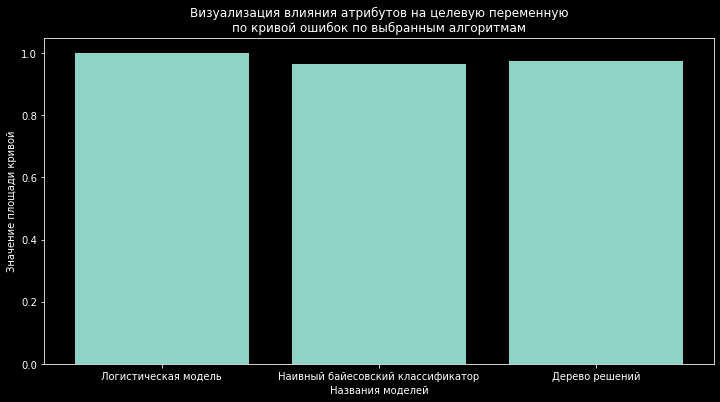

```python
x = ('Логистическая модель', 'Наивный байесовский классификатор', 'Дерево решений')
y = (list(model_logr[2].values())[2], list(model_gnb[2].values())[2], list(model_dtc[2].values())[2])

fig, ax = plt.subplots()

ax.bar(x, y)
ax.set_title('Визуализация влияния атрибутов на целевую переменную\nпо кривой ошибок по выбранным алгоритмам')
fig.set_figwidth(12)    #  ширина Figure
fig.set_figheight(6)    #  высота Figure

ax.set_ylabel('Значение площади кривой')
ax.set_xlabel('Названия моделей')
plt.show()
```

Интерпритация столбчатой диаграммы выше: диаграмма с кривой ошибок показывает хорошие результаты для всех алгоритмов. Но самый лучший из них также имеет логистическая регрессия - `0.99`. Это значит, что классификатор идиально обучен

### Визуализациия коррелируемых атрибутов к целевой переменной

Визуализируем все коррелируемые столбцы и рассмотрим результаты всех столбцов по отношению к целевой переменной(уровень опасности) - это `kmeans_preds_all`

```python
corr = df.corr()
corr.style.background_gradient(cmap='coolwarm')
```

|  | properties.id | properties.gibdd_id | properties.point.lat | properties.point.long | properties.participants_count | properties.injured_count | properties.dead_count | properties.scheme | Все участники | Дети | Пешеходы | Мотоциклисты | Велосипедисты | Общ. транспорт | Нерегулируемый перекрёсток неравнозначных улиц (дорог) | Объект торговли, общественного питания на автодороге вне НП | Нерегулируемый ж/д переезд | Эстакада, путепровод | Административные здания | Остановка общественного транспорта | Регулируемый перекресток | Регулируемый пешеходный переход | Остановка трамвая | Жилые дома индивидуальной застройки | Спортивные и развлекательные объекты | Многоквартирные жилые дома | Производственное предприятие | Аэропорт, ж/д вокзал (ж/д станция), речной или морской порт (пристань) | Нерегулируемый пешеходный переход | … |
| --- | --- | --- | --- | --- | --- | --- | --- | --- | --- | --- | --- | --- | --- | --- | --- | --- | --- | --- | --- | --- | --- | --- | --- | --- | --- | --- | --- | --- | --- | --- |
| properties.id | 1.000000 | 0.142476 | -0.109426 | 0.341379 | 0.004417 | 0.009091 | 0.005859 | 0.015777 | nan | 0.013022 | 0.000539 | -0.019188 | -0.019016 | -0.009047 | 0.030630 | -0.004825 | 0.000285 | -0.033963 | 0.012537 | -0.003482 | -0.011181 | 0.000798 | 0.023294 | 0.020661 | -0.000411 | -0.029227 | -0.000047 | -0.002754 | 0.019921 | … |
| properties.gibdd_id | 0.142476 | 1.000000 | 0.016715 | -0.001378 | 0.016785 | 0.008569 | -0.013180 | -0.012010 | nan | 0.007225 | -0.032484 | -0.025050 | 0.005200 | -0.009446 | 0.055909 | 0.003546 | -0.002341 | 0.015931 | 0.061185 | 0.062260 | 0.031614 | 0.058400 | 0.019052 | 0.037012 | 0.011997 | 0.019886 | 0.019076 | 0.006227 | 0.030684 | … |
| properties.point.lat | -0.109426 | 0.016715 | 1.000000 | -0.092261 | -0.007152 | -0.004986 | -0.042224 | 0.004395 | nan | -0.003768 | 0.010371 | -0.026879 | 0.003702 | 0.016423 | -0.058169 | -0.013813 | 0.000793 | 0.018273 | 0.002177 | 0.045060 | 0.042635 | 0.061081 | 0.013498 | -0.132854 | 0.011793 | 0.093488 | 0.025125 | 0.004759 | 0.016605 | … |
| properties.point.long | 0.341379 | -0.001378 | -0.092261 | 1.000000 | 0.002425 | 0.010649 | -0.005669 | 0.037463 | nan | 0.022328 | 0.005531 | -0.006472 | -0.029307 | -0.006685 | -0.006181 | 0.007234 | 0.003854 | -0.017159 | 0.071598 | 0.009600 | -0.010031 | 0.011509 | 0.032692 | 0.030070 | 0.019562 | 0.035523 | -0.003942 | 0.003434 | -0.004370 | … |
| properties.participants_count | 0.004417 | 0.016785 | -0.007152 | 0.002425 | 1.000000 | 0.714420 | 0.170837 | -0.362886 | nan | 0.180486 | -0.213662 | -0.114315 | -0.064828 | 0.016141 | 0.060552 | 0.017555 | 0.000757 | 0.011868 | 0.002355 | -0.006413 | 0.071045 | 0.000933 | -0.009693 | -0.035069 | -0.001197 | -0.040490 | 0.005990 | -0.003750 | -0.074124 | … |
| properties.injured_count | 0.009091 | 0.008569 | -0.004986 | 0.010649 | 0.714420 | 1.000000 | -0.110957 | -0.203116 | nan | 0.175152 | -0.233738 | -0.056710 | -0.061922 | -0.001371 | 0.033937 | 0.004720 | 0.000455 | 0.003773 | -0.017760 | -0.035385 | 0.034704 | -0.024521 | -0.014745 | -0.021865 | -0.006200 | -0.067450 | 0.002930 | -0.005179 | -0.081633 | … |
| properties.dead_count | 0.005859 | -0.013180 | -0.042224 | -0.005669 | 0.170837 | -0.110957 | 1.000000 | -0.004007 | nan | -0.008827 | -0.001307 | -0.010708 | -0.015754 | -0.014285 | -0.050960 | 0.015310 | -0.000111 | -0.002026 | -0.064489 | -0.053236 | -0.073101 | -0.062012 | -0.021065 | -0.018591 | -0.021026 | -0.123914 | -0.012989 | -0.008238 | -0.051346 | … |
| properties.scheme | 0.015777 | -0.012010 | 0.004395 | 0.037463 | -0.362886 | -0.203116 | -0.004007 | 1.000000 | nan | 0.036033 | 0.577274 | -0.065132 | -0.090317 | 0.032926 | -0.068829 | -0.009480 | -0.000790 | -0.028555 | 0.013677 | 0.064890 | -0.091113 | 0.029703 | 0.034264 | 0.043008 | 0.013544 | 0.107159 | -0.018380 | 0.011611 | 0.169923 | … |
| Все участники | nan | nan | nan | nan | nan | nan | nan | nan | nan | nan | nan | nan | nan | nan | nan | nan | nan | nan | nan | nan | nan | nan | nan | nan | nan | nan | nan | nan | nan | … |
| Дети | 0.013022 | 0.007225 | -0.003768 | 0.022328 | 0.180486 | 0.175152 | -0.008827 | 0.036033 | nan | 1.000000 | 0.100178 | -0.018026 | 0.087070 | -0.010164 | 0.003819 | -0.004520 | -0.004698 | -0.012969 | -0.008627 | 0.005105 | -0.009435 | 0.010611 | -0.004007 | 0.035582 | 0.016863 | 0.048725 | -0.021461 | -0.005425 | 0.054197 | … |
| Пешеходы | 0.000539 | -0.032484 | 0.010371 | 0.005531 | -0.213662 | -0.233738 | -0.001307 | 0.577274 | nan | 0.100178 | 1.000000 | -0.133242 | -0.110627 | -0.021790 | -0.097590 | -0.000845 | -0.010460 | -0.033488 | 0.055634 | 0.135302 | -0.062762 | 0.120743 | 0.050637 | 0.020839 | 0.029066 | 0.214542 | -0.012782 | 0.018323 | 0.353445 | … |
| Мотоциклисты | -0.019188 | -0.025050 | -0.026879 | -0.006472 | -0.114315 | -0.056710 | -0.010708 | -0.065132 | nan | -0.018026 | -0.133242 | 1.000000 | -0.025232 | -0.021164 | 0.050463 | -0.002256 | 0.001951 | -0.001523 | -0.011437 | -0.031069 | -0.022976 | -0.037909 | -0.015794 | 0.079632 | -0.002782 | -0.028809 | 0.000309 | -0.003411 | -0.042877 | … |
| Велосипедисты | -0.019016 | 0.005200 | 0.003702 | -0.029307 | -0.064828 | -0.061922 | -0.015754 | -0.090317 | nan | 0.087070 | -0.110627 | -0.025232 | 1.000000 | -0.010297 | 0.034440 | -0.006522 | -0.000692 | -0.007055 | -0.002417 | -0.020085 | -0.011931 | -0.004644 | -0.008612 | 0.048657 | 0.005408 | 0.014212 | -0.004008 | -0.004154 | 0.001754 | … |
| Общ. транспорт | -0.009047 | -0.009446 | 0.016423 | -0.006685 | 0.016141 | -0.001371 | -0.014285 | 0.032926 | nan | -0.010164 | -0.021790 | -0.021164 | -0.010297 | 1.000000 | -0.013721 | -0.004418 | -0.001916 | -0.003602 | 0.033199 | 0.062947 | 0.013767 | 0.027718 | 0.118463 | -0.022081 | 0.010371 | 0.042702 | 0.001221 | 0.006540 | -0.011392 | … |
| Нерегулируемый перекрёсток неравнозначных улиц (дорог) | 0.030630 | 0.055909 | -0.058169 | -0.006181 | 0.060552 | 0.033937 | -0.050960 | -0.068829 | nan | 0.003819 | -0.097590 | 0.050463 | 0.034440 | -0.013721 | 1.000000 | 0.017917 | 0.003119 | -0.003248 | 0.018350 | -0.019705 | -0.141374 | -0.107474 | -0.018170 | 0.144565 | 0.006707 | -0.001381 | 0.002507 | -0.004972 | 0.123325 | … |
| Объект торговли, общественного питания на автодороге вне НП | -0.004825 | 0.003546 | -0.013813 | 0.007234 | 0.017555 | 0.004720 | 0.015310 | -0.009480 | nan | -0.004520 | -0.000845 | -0.002256 | -0.006522 | -0.004418 | 0.017917 | 1.000000 | 0.001430 | 0.000185 | -0.017393 | 0.002171 | -0.004850 | -0.011531 | -0.006544 | -0.012746 | -0.005321 | -0.034688 | -0.006056 | -0.002258 | 0.003522 | … |
| Нерегулируемый ж/д переезд | 0.000285 | -0.002341 | 0.000793 | 0.003854 | 0.000757 | 0.000455 | -0.000111 | -0.000790 | nan | -0.004698 | -0.010460 | 0.001951 | -0.000692 | -0.001916 | 0.003119 | 0.001430 | 1.000000 | -0.001322 | 0.000476 | -0.003541 | -0.007216 | -0.009021 | -0.002843 | -0.001587 | -0.002482 | -0.015722 | 0.033352 | 0.005297 | -0.005470 | … |
| Эстакада, путепровод | -0.033963 | 0.015931 | 0.018273 | -0.017159 | 0.011868 | 0.003773 | -0.002026 | -0.028555 | nan | -0.012969 | -0.033488 | -0.001523 | -0.007055 | -0.003602 | -0.003248 | 0.000185 | -0.001322 | 1.000000 | -0.001048 | -0.009737 | -0.005932 | -0.010633 | -0.005427 | -0.025706 | -0.004239 | -0.014933 | 0.014431 | 0.005740 | -0.025360 | … |
| Административные здания | 0.012537 | 0.061185 | 0.002177 | 0.071598 | 0.002355 | -0.017760 | -0.064489 | 0.013677 | nan | -0.008627 | 0.055634 | -0.011437 | -0.002417 | 0.033199 | 0.018350 | -0.017393 | 0.000476 | -0.001048 | 1.000000 | 0.120197 | 0.132842 | 0.127860 | 0.054576 | -0.043494 | 0.054747 | 0.127104 | 0.049648 | 0.022082 | 0.060203 | … |
| Остановка общественного транспорта | -0.003482 | 0.062260 | 0.045060 | 0.009600 | -0.006413 | -0.035385 | -0.053236 | 0.064890 | nan | 0.005105 | 0.135302 | -0.031069 | -0.020085 | 0.062947 | -0.019705 | 0.002171 | -0.003541 | -0.009737 | 0.120197 | 1.000000 | 0.117599 | 0.219729 | 0.096961 | -0.043155 | 0.044688 | 0.136086 | 0.029818 | 0.025941 | 0.238251 | … |
| Регулируемый перекресток | -0.011181 | 0.031614 | 0.042635 | -0.010031 | 0.071045 | 0.034704 | -0.073101 | -0.091113 | nan | -0.009435 | -0.062762 | -0.022976 | -0.011931 | 0.013767 | -0.141374 | -0.004850 | -0.007216 | -0.005932 | 0.132842 | 0.117599 | 1.000000 | 0.431561 | 0.064499 | -0.051143 | 0.040969 | 0.187173 | 0.003753 | 0.010083 | -0.133512 | … |
| Регулируемый пешеходный переход | 0.000798 | 0.058400 | 0.061081 | 0.011509 | 0.000933 | -0.024521 | -0.062012 | 0.029703 | nan | 0.010611 | 0.120743 | -0.037909 | -0.004644 | 0.027718 | -0.107474 | -0.011531 | -0.009021 | -0.010633 | 0.127860 | 0.219729 | 0.431561 | 1.000000 | 0.096582 | -0.069462 | 0.035213 | 0.194623 | -0.004030 | 0.013080 | -0.140362 | … |
| Остановка трамвая | 0.023294 | 0.019052 | 0.013498 | 0.032692 | -0.009693 | -0.014745 | -0.021065 | 0.034264 | nan | -0.004007 | 0.050637 | -0.015794 | -0.008612 | 0.118463 | -0.018170 | -0.006544 | -0.002843 | -0.005427 | 0.054576 | 0.096961 | 0.064499 | 0.096582 | 1.000000 | -0.027726 | 0.012462 | 0.043248 | 0.008233 | 0.004897 | 0.026319 | … |
| Жилые дома индивидуальной застройки | 0.020661 | 0.037012 | -0.132854 | 0.030070 | -0.035069 | -0.021865 | -0.018591 | 0.043008 | nan | 0.035582 | 0.020839 | 0.079632 | 0.048657 | -0.022081 | 0.144565 | -0.012746 | -0.001587 | -0.025706 | -0.043494 | -0.043155 | -0.051143 | -0.069462 | -0.027726 | 1.000000 | -0.024918 | -0.164677 | -0.027497 | -0.012566 | 0.021149 | … |
| Спортивные и развлекательные объекты | -0.000411 | 0.011997 | 0.011793 | 0.019562 | -0.001197 | -0.006200 | -0.021026 | 0.013544 | nan | 0.016863 | 0.029066 | -0.002782 | 0.005408 | 0.010371 | 0.006707 | -0.005321 | -0.002482 | -0.004239 | 0.054747 | 0.044688 | 0.040969 | 0.035213 | 0.012462 | -0.024918 | 1.000000 | 0.036861 | -0.003751 | 0.003039 | 0.033885 | … |
| Многоквартирные жилые дома | -0.029227 | 0.019886 | 0.093488 | 0.035523 | -0.040490 | -0.067450 | -0.123914 | 0.107159 | nan | 0.048725 | 0.214542 | -0.028809 | 0.014212 | 0.042702 | -0.001381 | -0.034688 | -0.015722 | -0.014933 | 0.127104 | 0.136086 | 0.187173 | 0.194623 | 0.043248 | -0.164677 | 0.036861 | 1.000000 | -0.048842 | 0.000627 | 0.166089 | … |
| Производственное предприятие | -0.000047 | 0.019076 | 0.025125 | -0.003942 | 0.005990 | 0.002930 | -0.012989 | -0.018380 | nan | -0.021461 | -0.012782 | 0.000309 | -0.004008 | 0.001221 | 0.002507 | -0.006056 | 0.033352 | 0.014431 | 0.049648 | 0.029818 | 0.003753 | -0.004030 | 0.008233 | -0.027497 | -0.003751 | -0.048842 | 1.000000 | 0.000495 | 0.001873 | … |
| Аэропорт, ж/д вокзал (ж/д станция), речной или морской порт (пристань) | -0.002754 | 0.006227 | 0.004759 | 0.003434 | -0.003750 | -0.005179 | -0.008238 | 0.011611 | nan | -0.005425 | 0.018323 | -0.003411 | -0.004154 | 0.006540 | -0.004972 | -0.002258 | 0.005297 | 0.005740 | 0.022082 | 0.025941 | 0.010083 | 0.013080 | 0.004897 | -0.012566 | 0.003039 | 0.000627 | 0.000495 | 1.000000 | 0.012759 | … |
| Нерегулируемый пешеходный переход | 0.019921 | 0.030684 | 0.016605 | -0.004370 | -0.074124 | -0.081633 | -0.051346 | 0.169923 | nan | 0.054197 | 0.353445 | -0.042877 | 0.001754 | -0.011392 | 0.123325 | 0.003522 | -0.005470 | -0.025360 | 0.060203 | 0.238251 | -0.133512 | -0.140362 | 0.026319 | 0.021149 | 0.033885 | 0.166089 | 0.001873 | 0.012759 | 1.000000 | … |
| Нерегулируемый перекрёсток равнозначных улиц (дорог) | 0.000196 | 0.015456 | -0.012705 | -0.004475 | -0.003289 | -0.003931 | -0.019043 | -0.000922 | nan | 0.015775 | -0.019725 | 0.031365 | 0.031637 | -0.005105 | -0.043604 | -0.000961 | 0.000109 | -0.000189 | -0.007423 | -0.023003 | -0.036106 | -0.030582 | -0.007605 | 0.060712 | -0.003238 | -0.005386 | -0.002340 | 0.001123 | 0.002039 | … |

[output cut: 122 more lines]

Интерпретация корреляционной карты: на данной карте необходимо получить информацию только о целевой переменной `kmeans_preds_all` по отношению ко всем атрибутам(это и есть визуализация вляиния атрибутов на определение уровня опсности). Как видно из представленной выше карты, можно сказать, что `kmeans_preds_all` сильно коррелирует с такими признаками, как `properties.participants_count`, `properties.injured_count`, `properties.scheme`, `Пешеходы`, `Остановка общественного транспорта`, `Многоквартирные жилые дома`, `Нерегулируемый пешеходный переход`, `Столкновение`. Самое сильное коррелируемое значение имеют два последник признака. Это можно объяснить тем, что, скорее всего, ДТП чеще всего возникали, как на пешеходном переходе, так и по случаю столкновения автомобилей

### Выбор модели классификации

Я выбираю модель, основанную на `логистической регрессии`, поскольку уровень точности у неё больше чем у остальных. Точность данной модели составляет - `0.99`

## 3.4 Feature Engineering

Чтобы сгенерировать новые данные, обратимся к столбцу жертв ДТП(`properties.dead_count`). Сгенерируем новые метки таким образом, чтобы вслучае получения информации, если есть хотя-бы одна жертва в ДТП, то данный случай будет назван, как `опасный`. В противном случае `менее опасный`. Атрибут новых данных будет назван, как `new_metka`

```python
df['new_metka']=np.nan
df['new_metka']=df['properties.dead_count'].replace({0: 'менее опасный'})
df['new_metka'] = df['new_metka'].str.replace('\d+', '')
df['new_metka']=df['new_metka'].replace(np.nan, 'опасный')
```

```python
df['new_metka_val']=df['new_metka'].replace({'менее опасный':1,'опасный':0})
```

```python
df['new_metka_val'].value_counts()
```

```
1    838478
0     89975
Name: new_metka_val, dtype: int64
```

```python
df.head()
```

|  | properties.id | properties.gibdd_id | properties.point.lat | properties.point.long | properties.participant_categories | properties.severity | properties.region | properties.parent_region | properties.datetime | properties.address | properties.participants_count | properties.injured_count | properties.dead_count | properties.category | properties.light | properties.nearby | properties.weather | properties.road_conditions | properties.vehicles | properties.participants | properties.tags | properties.scheme | Все участники | Дети | Пешеходы | Мотоциклисты | Велосипедисты | Общ. транспорт | Нерегулируемый перекрёсток неравнозначных улиц (дорог) | … |
| --- | --- | --- | --- | --- | --- | --- | --- | --- | --- | --- | --- | --- | --- | --- | --- | --- | --- | --- | --- | --- | --- | --- | --- | --- | --- | --- | --- | --- | --- | --- |
| 0 | 2312860 | 191156006 | 53.775400 | 82.667800 | ['Все участники'] | Легкий | Павловский район | Алтайский край | 2016-02-16 21:50:00 | Барнаул - Камень-на-Оби - граница Новосибирско... | 3 | 1 | 0 | Столкновение | В темное время суток, освещение отсутствует | [] | ['Ясно'] | ['Сухое'] | [{'brand': 'NISSAN', 'model': 'Serena', 'color... | [] | ['Дорожно-транспортные происшествия'] | 210 | 1 | 0 | 0 | 0 | 0 | 0 | 0 | … |
| 1 | 2310071 | 220071393 | 53.401953 | 82.236507 | ['Все участники'] | Тяжёлый | Шелаболихинский район | Алтайский край | 2019-11-04 01:10:00 | Барнаул - Камень-на-Оби - граница Новосибирско... | 1 | 1 | 0 | Опрокидывание | В темное время суток, освещение отсутствует | [] | ['Пасмурно'] | ['Сухое'] | [{'brand': 'TOYOTA', 'model': 'Corolla', 'colo... | [] | ['Дорожно-транспортные происшествия'] | 950 | 1 | 0 | 0 | 0 | 0 | 0 | 0 | … |
| 2 | 2311255 | 206911348 | 53.324525 | 83.007579 | ['Все участники'] | Легкий | Павловский район | Алтайский край | 2017-09-25 11:50:00 | Барнаул - Камень-на-Оби - граница Новосибирско... | 3 | 2 | 0 | Столкновение | Светлое время суток | [] | ['Пасмурно'] | ['Сухое'] | [{'brand': 'MITSUBISHI', 'model': 'Pajero', 'c... | [] | ['Дорожно-транспортные происшествия'] | 60 | 1 | 0 | 0 | 0 | 0 | 0 | 0 | … |
| 3 | 2308403 | 213560316 | 53.320377 | 82.917423 | ['Дети', 'Все участники'] | Тяжёлый | Павловский район | Алтайский край | 2018-11-03 11:00:00 | Павловск - Ребриха - Буканское, 65 км | 4 | 2 | 0 | Столкновение | Светлое время суток | [] | ['Снегопад'] | ['Сухое'] | [{'brand': 'ВАЗ', 'model': 'ВАЗ 2110, 21101, 2... | [] | ['Дорожно-транспортные происшествия', 'ДТП и п... | 220 | 1 | 1 | 0 | 0 | 0 | 0 | 0 | … |
| 4 | 2313040 | 191027864 | 52.988900 | 82.155600 | ['Все участники'] | Легкий | Ребрихинский район | Алтайский край | 2016-02-02 04:20:00 | Павловск - Ребриха - Буканское, 65 км | 2 | 1 | 0 | Опрокидывание | В темное время суток, освещение отсутствует | ['Нерегулируемый перекрёсток'] | ['Пасмурно'] | ['Обработанное противогололедными материалами'] | [{'brand': 'DAF', 'model': 'CF-series', 'color... | [] | ['Дорожно-транспортные происшествия'] | 600 | 1 | 0 | 0 | 0 | 0 | 0 | 0 | … |

Такиим образом мы получаем метки, которые были сгенерированны на основе жертв ДТП. Теперь обучим модель на новых данных и сравним показатели с лучшей моделью, полученной ранее на этом же алгоритме

```python
features=df.drop(['properties.id', 'properties.gibdd_id', 'properties.point.lat', 'properties.point.long',
           'properties.participant_categories', 'properties.severity', 'properties.region',
           'properties.parent_region', 'properties.datetime', 'properties.address', 'properties.category',
           'properties.light', 'properties.nearby', 'properties.weather', 'properties.road_conditions',
           'properties.vehicles', 'properties.participants', 'properties.tags', 'properties.scheme',
                  'kmeans_preds_all','named_roads', 'new_metka', 'new_metka_val'],axis=1)

scaler=StandardScaler()
X=scaler.fit_transform(features)
```

```python
#1/3 - это значит, что тестовая выборка будет иметь 0.33 данных
from sklearn.model_selection import train_test_split
X_train, X_test, y_train, y_test = train_test_split(X, df['new_metka_val'], test_size=0.33, random_state=42, shuffle=True)
```

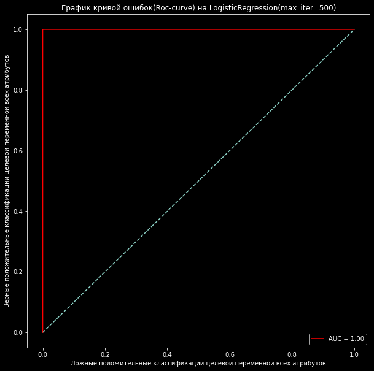

```python
model_logr_new=get_model(LogisticRegression(max_iter=500), X_train, X_test, y_train, y_test)
```

```python
json_normalize(model_logr_new[2])
```

|  | Точность | Функция потерь | Кривая ошибки |
| --- | --- | --- | --- |
| 0 | 1.0 | 9.992007e-16 | 1.0 |

Как видим при ручной настройке данных результат получился лучше. Теперь модель имеет точность а целую `1`, по сравнению с тем, что было ранее - это `0.99`.

**Обоснование выбора финальной модели: по результатам сравнения получется, что модель обученная на новых данных имеет лучший показатель из всех возможнох, поэтому я выбирая модель логистической регрессии на новых данных, поскольку её точность является лучшей из всех - это целая `1`**

```python
#Сохранение результирующего набора данных
df.to_csv('result_data_new.csv', sep='\t', encoding='utf-8-sig')
```

## 3.5 Визуализация данных по географическим признакам

Чтобы визуализировать эти данные, необходимо обратиться к библиотеке `Folium`, которая способна визуализировать интерактивные данные на карте. Её аналог - это `plotly`, которая также способна визуализировать данные, только на графике(интерактивно), но она сложна в освоении, чем `matplotlib`

Определим, что у нас есть 3 географических признака - это долгота, широта и адреса. Но по адресу мы не будем ничего визуализировать, так как широты и долготы будет вполне достаточно для визуализации. Но, на метках можно поставить текст с адресом, чтобы точнее определить местоположение аварии

Определим, что повышенным уровнем опасности располагает атрибут `new_metka_val`. На основе него и сделаем интерактивную карту

```python
import folium
from folium.plugins import MarkerCluster
```

```python
df['new_metka_val_true_false']=df['new_metka_val'].astype(bool)
```

```python
#Данные визуализации
lat = df['properties.point.lat']
lon = df['properties.point.long']
adress = df['properties.address']
dangerous_data=df['new_metka_val_true_false']

#Функция раскрашивания меток. Если опасный участок дороги, то окрашивается красным, в противном случае жёлтым
def color_change(elev):
    if(elev == 1):
        return('orange')
    else:
        return('red')

#Объявление карты
map = folium.Map(location=[54.731111, 55.988135], zoom_start = 5)

#!!!!Крастеризация меток по количеству, не по краскам, но метки всё равно получили цвет по уровню опасности ДТП
marker_cluster = MarkerCluster().add_to(map)

#Визуализация
for lat, lon, adress, dangerous_data in zip(lat, lon, adress, dangerous_data):
    folium.CircleMarker(location=[lat, lon], radius = 9, popup=str(adress)+" m", fill_color=color_change(dangerous_data), color="gray", fill_opacity = 0.9).add_to(marker_cluster)
```

## 3.6 Подготовка отчета

В данной сессии было сделано:

- 3.1 Визуализация зависимостей данных - выбранны способы визуализации, интерпретированны графики
- 3.2 Классификация дорожных объектов - было выбранно 3 алгоритма классификации
- 3.3 Обучение - дорожные объекты были классифицированны, полученная модель имеет точность 0.99 на логистической крегрессии
- 3.4 Feature Engineering - благодаря Feature Engineering были сгенерированны новые данные на основе жертв ДТП, а также новая модель того же алгоритма на новых данных имеет улучшенный результат точности `1`
- 3.5 Визуализация данных по географическим признакам - вызуализация интерактивной карты была сделана с помошью folium на основе данных о долготе, широте и адресу